# Week 2 Basic Classification Models: knn, Decision Trees, and Logistic Regressions

# k-Nearest Neighbor (kNN): A Lazy Classification Model

First, a [visualization] (http://blog.yhat.com/posts/classification-using-knn-and-python.html)

kNN is called a “lazy learner” because it does not perform abstraction. Lantz (2013) noted:

*In a single sentence, nearest neighbor classifiers are defined by their characteristics of classifying unlabeled examples by assigning them the class of the most similar labeled examples* (Lantz 2013, p. 66).

When comparing among neighbors, we need to use a distance function. The most common way to measure distance is **Euclidean distance**, or the shortest direct route.

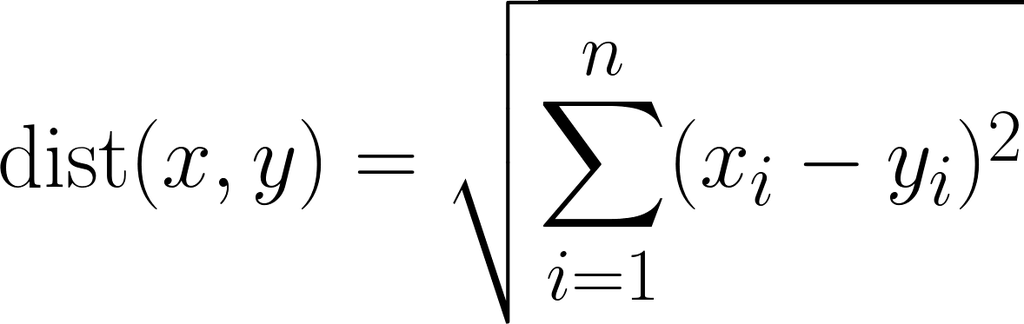

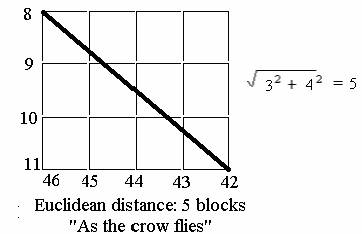

# How many neighbors (k)?

When choosing the number of k, we need to consider the **bias-variance tradeoff**. A large k reduces the variance caused by noisy data but can cause bias in that we risk ignoring small (and important) patterns (Lantz 2013, p. 71).

# kNN requires data transformation into a standard range

## Min-Max Normalization

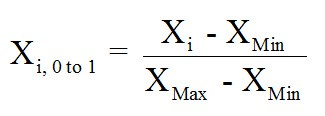

Also see page 73 of Lantz text

In our prescribers dataset, we have two factors: Gender and Opioid.Prescriber. We will leave the Opioid.Prescriber alone since this is our target variable. We need to change Gender into a dummy variable so that it will be on the same 0,1 scale as our other variables (once we perform min-max normalization).

```r
prescribers$Male <-ifelse(prescribers$Gender=="M",1,0) #if Male = 1; if Female=0.
prescribers<-prescribers[,-2] #We do not need the Gender variable anymore.

#names(prescribers)
```

Here is the breakdown of the 331 variables:

Column 1: target variable

Columns 2-240: number of prescriptions written for each non-opioid drug

Columns 241-291: state dummy variables

Columns 292-330: medical speciality dummy variables

Column 331: dummy variable for male (i.e. gender)

We need to do min-max normalization for columns 2-240 and then add that with our other colums (already on the 0-1 scale).

```r
drugs<-prescribers[,2:240]
normalize<- function(x){return((x-min(x))/(max(x)-min(x)))}
drugs_n<-as.data.frame(lapply(drugs, normalize))
```

Let’s check our work to see if we did it correctly!

```r
summary(drugs$ABILIFY) #Range was between 0 and 770
```

```
##    Min. 1st Qu.  Median    Mean 3rd Qu.    Max.
##   0.000   0.000   0.000   3.157   0.000 770.000
```

```r
summary(drugs_n$ABILIFY) #Notice the range is now between 0 and 1
```

```
##    Min. 1st Qu.  Median    Mean 3rd Qu.    Max.
##  0.0000  0.0000  0.0000  0.0041  0.0000  1.0000
```

Now we are going to combine the normalized variables with our dummy variables and the target variable.

```r
prescribers_n<-cbind(prescribers[,c(1,241:331)], drugs_n[,])

prescribers_n<-prescribers_n[complete.cases(prescribers_n),]
```